# Homework 3

Name1, Name2, Name3

2019-03-25

## Load packages

```r
library(ggplot2)
library(dplyr)
library(stringr)
library(nycflights13)
library(DBI)
```

## Questions

0. (0 marks) If you haven’t already, install the `nycflights13` package and read the help files on the `flights` and `airlines` tables.

```r
data(flights)
data(airlines)
head(flights)
```

```
## # A tibble: 6 x 19
##    year month   day dep_time sched_dep_time dep_delay arr_time
##   <int> <int> <int>    <int>          <int>     <dbl>    <int>
## 1  2013     1     1      517            515         2      830
## 2  2013     1     1      533            529         4      850
## 3  2013     1     1      542            540         2      923
## 4  2013     1     1      544            545        -1     1004
## 5  2013     1     1      554            600        -6      812
## 6  2013     1     1      554            558        -4      740
## # ... with 12 more variables: sched_arr_time <int>, arr_delay <dbl>,
## #   carrier <chr>, flight <int>, tailnum <chr>, origin <chr>, dest <chr>,
## #   air_time <dbl>, distance <dbl>, hour <dbl>, minute <dbl>,
## #   time_hour <dttm>
```

```r
head(airlines)
```

```
## # A tibble: 6 x 2
##   carrier name
##   <chr>   <chr>
## 1 9E      Endeavor Air Inc.
## 2 AA      American Airlines Inc.
## 3 AS      Alaska Airlines Inc.
## 4 B6      JetBlue Airways
## 5 DL      Delta Air Lines Inc.
## 6 EV      ExpressJet Airlines Inc.
```

1. (1 mark) Use `dplyr` functions to perform an inner join between the `airlines` table and the `flights` table on `carrier` and then select the variables `carrier`, `name`, `month`, `day`, `dep_time` and `dep_delay`. Save your dataframe in `flights`.

```r
flights %>% inner_join(airlines, by = 'carrier') %>% select(carrier, name, month, day, dep_time, dep_delay) -> flights
head(flights)
```

```
## # A tibble: 6 x 6
##   carrier name                   month   day dep_time dep_delay
##   <chr>   <chr>                  <int> <int>    <int>     <dbl>
## 1 UA      United Air Lines Inc.      1     1      517         2
## 2 UA      United Air Lines Inc.      1     1      533         4
## 3 AA      American Airlines Inc.     1     1      542         2
## 4 B6      JetBlue Airways            1     1      544        -1
## 5 DL      Delta Air Lines Inc.       1     1      554        -6
## 6 UA      United Air Lines Inc.      1     1      554        -4
```

2. (2 marks) Remove Inc., Co. and Corporation from the airline names in the `name` variable of `flights`. Then shorten the phrases “Airlines”, “Air Lines”, and “Airways” to just “Air”. Print out the unique values of `flights$name`.

```r
pattern1 <- "Inc."
pattern2 <- 'Co.'
pattern3 <- "Corporation"
pattern4 <- 'Airlines'
pattern5 <- "Air Lines"
pattern6 <- "Airways"
flights$name %>% str_replace_all(pattern = pattern1, replacement = "") %>% str_replace_all(pattern2, "") %>% str_replace_all(pattern3, "") %>% str_replace_all(pattern4, "Air") %>% str_replace_all(pattern5, "Air") %>% str_replace_all(pattern6, "Air") -> flights$name
unique(flights$name)
```

```
##  [1] "United Air "          "American Air "        "JetBlue Air"
##  [4] "Delta Air "           "ExpressJet Air "      "Envoy Air"
##  [7] "US Air "              "Southwest Air "       "Virgin America"
## [10] "AirTran Air poration" "Alaska Air "          "Endeavor Air "
## [13] "Frontier Air "        "Hawaiian Air "        "Mesa Air "
## [16] "SkyWest Air "
```

3. (2 marks) Select the flights from January. Calculate the median departure delay for each airline on each day and save the results in a dataframe called fldelaysJan. Plot median delay versus day, with different facets for each airline. (Note that the `median()` function in R has an argument `na.rm` that you may wish to set to `FALSE`.) Use the `name` variable to specify airlines (instead of `carrier`) so that the labels on your facets are informative. Do **not** free the scales on the facets.

```r
# Make data and lists for function inputs
library(tidyverse)
flights %>% filter(month == 1) %>% select(name, dep_delay, day)-> Jan_flt
name <- as.list(unique(Jan_flt$name))
days <- as.list(1:31)
```

```r
# Make a function to calculate medians
med_calculator <- function(names,d, data) {
    fs <- vector("double", length(names))

  for (i in seq_along(names)) {

  data %>% filter(day == d) %>% filter(name == names[[i]]) %>% select(dep_delay) %>% unlist() %>% median(na.rm = TRUE) -> fs[i]
  }
  fs
}

# Loop through all days in January
# and stack dataframe
fldelaysJan <- data.frame()
for (i in 1:31){
   df <- data.frame(day = i, name = unlist(name), med_del = med_calculator(name, i, Jan_flt))
   fldelaysJan <- rbind(fldelaysJan, df)
}
head(fldelaysJan)
```

```
##   day            name med_del
## 1   1     United Air      2.0
## 2   1   American Air     -2.0
## 3   1     JetBlue Air     0.5
## 4   1      Delta Air     -3.5
## 5   1 ExpressJet Air     10.0
## 6   1       Envoy Air    -2.0
```

```
## geom_path: Each group consists of only one observation. Do you need to
## adjust the group aesthetic?
```

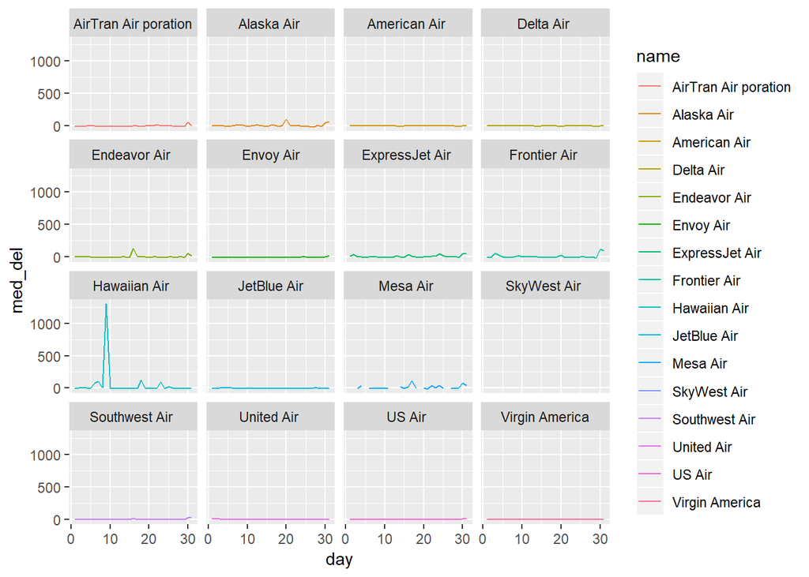

```r
#Plot
ggplot(fldelaysJan, aes(x = day, y = med_del, color = name )) + geom_line() + facet_wrap(~name)
```

4. (2 marks) The plot in part (3) is not very informative because one airline had a very long median flight delay on one day in January. Remove this **one observation** from `fldelaysJan`. Also remove the airline that had flights on only one day. Now redo the plot in (3). Again, do **not** free the scales on the facets.

```r
outlier <- max(fldelaysJan$med_del, na.rm = TRUE)
fldelaysJan <- fldelaysJan[-which(fldelaysJan$med_del == outlier),]
fldelaysJan <- fldelaysJan[-which(fldelaysJan$name == "SkyWest Air"),]
fldelaysJan
```

```
## [1] day     name    med_del
## <0 rows> (or 0-length row.names)
```